# Avocado Prices Exploration

By Jacob Song

### Introduction

So what's the deal with **Avocados**?

They're savory, buttery, rich and creamy, something you would never expect from ordinary, most-of-the-time sweet fruits. With the health benefits of avocados, the ever-rising demands of "avocado toasts" and as the main ingredient of guacamole, avocados warrant their popularity of demands and their extragavent-than-average prices.

So can Exploratory Data Analysis tell us something about the price fluctuation of avocados?

```python
# Using Python libraries such as numpy, pandas, pyplot, and seaborn for exploratory data analysis
import numpy as np
import pandas as pd
import matplotlib.pyplot as plt
import seaborn as sns
from scipy.stats import norm
```

Relevant Columns of the dataset:

- `Date` - the date of the observation
- `AveragePrice` - the average price of a single avocado
- `type` - conventional or organic
- `year` - the year
- `Region` - the city or region of the observation
- `Total Volume` - total nmber of avocados sold
- `4046` - total number of avocados with PLU 4046 sold
- `4225` - total number of avocados with PLU 4225 sold
- `4770` - total number of avocados with PLU 4770 sold

*PLU - Price Look Up (for supermarket checkout systems)*

```python
# Reading the dataset for EDA
avocado = pd.read_csv("avocado-prices/avocado.csv")
avocado.head()
```

|  | Unnamed: 0 | Date | AveragePrice | Total Volume | 4046 | 4225 | 4770 | Total Bags | Small Bags | Large Bags | XLarge Bags | type | year | region |
| --- | --- | --- | --- | --- | --- | --- | --- | --- | --- | --- | --- | --- | --- | --- |
| 0 | 0 | 2015-12-27 | 1.33 | 64236.62 | 1036.74 | 54454.85 | 48.16 | 8696.87 | 8603.62 | 93.25 | 0.0 | conventional | 2015 | Albany |
| 1 | 1 | 2015-12-20 | 1.35 | 54876.98 | 674.28 | 44638.81 | 58.33 | 9505.56 | 9408.07 | 97.49 | 0.0 | conventional | 2015 | Albany |
| 2 | 2 | 2015-12-13 | 0.93 | 118220.22 | 794.70 | 109149.67 | 130.50 | 8145.35 | 8042.21 | 103.14 | 0.0 | conventional | 2015 | Albany |
| 3 | 3 | 2015-12-06 | 1.08 | 78992.15 | 1132.00 | 71976.41 | 72.58 | 5811.16 | 5677.40 | 133.76 | 0.0 | conventional | 2015 | Albany |
| 4 | 4 | 2015-11-29 | 1.28 | 51039.60 | 941.48 | 43838.39 | 75.78 | 6183.95 | 5986.26 | 197.69 | 0.0 | conventional | 2015 | Albany |

```python
avocado.tail()
```

|  | Unnamed: 0 | Date | AveragePrice | Total Volume | 4046 | 4225 | 4770 | Total Bags | Small Bags | Large Bags | XLarge Bags | type | year | region |
| --- | --- | --- | --- | --- | --- | --- | --- | --- | --- | --- | --- | --- | --- | --- |
| 18244 | 7 | 2018-02-04 | 1.63 | 17074.83 | 2046.96 | 1529.20 | 0.00 | 13498.67 | 13066.82 | 431.85 | 0.0 | organic | 2018 | WestTexNewMexico |
| 18245 | 8 | 2018-01-28 | 1.71 | 13888.04 | 1191.70 | 3431.50 | 0.00 | 9264.84 | 8940.04 | 324.80 | 0.0 | organic | 2018 | WestTexNewMexico |
| 18246 | 9 | 2018-01-21 | 1.87 | 13766.76 | 1191.92 | 2452.79 | 727.94 | 9394.11 | 9351.80 | 42.31 | 0.0 | organic | 2018 | WestTexNewMexico |
| 18247 | 10 | 2018-01-14 | 1.93 | 16205.22 | 1527.63 | 2981.04 | 727.01 | 10969.54 | 10919.54 | 50.00 | 0.0 | organic | 2018 | WestTexNewMexico |
| 18248 | 11 | 2018-01-07 | 1.62 | 17489.58 | 2894.77 | 2356.13 | 224.53 | 12014.15 | 11988.14 | 26.01 | 0.0 | organic | 2018 | WestTexNewMexico |

### Data Tidying

For exploratory data analysis, the dataset should go through the process of data tidying to facilitate effective data analysis.

```python
# Checking for any null in the dataset
avocado.isnull().sum()
```

```
Unnamed: 0      0
Date            0
AveragePrice    0
Total Volume    0
4046            0
4225            0
4770            0
Total Bags      0
Small Bags      0
Large Bags      0
XLarge Bags     0
type            0
year            0
region          0
dtype: int64
```

In our Avocado dataset, it seems that the dataset is already "tidy" enough as is.

```python
# Removing Unnamed: 0 (It was #) since we already have indices
avocado = avocado.drop("Unnamed: 0", 1)

# Saving a copy of avocado dataset with datetime format instead (since it was just an object)
avocadoDate = avocado

# Splitting date into 3 different columns
avocado["Year"], avocado["Month"], avocado["Day"] = avocado["Date"].str.split("-").str
avocado.head()

# Having the date in datetime format too make some other parts of visualization easier
avocadoDate["Date"] = pd.to_datetime(avocadoDate["Date"])

avocado.head()
```

|  | Date | AveragePrice | Total Volume | 4046 | 4225 | 4770 | Total Bags | Small Bags | Large Bags | XLarge Bags | type | year | region | Year | Month | Day |
| --- | --- | --- | --- | --- | --- | --- | --- | --- | --- | --- | --- | --- | --- | --- | --- | --- |
| 0 | 2015-12-27 | 1.33 | 64236.62 | 1036.74 | 54454.85 | 48.16 | 8696.87 | 8603.62 | 93.25 | 0.0 | conventional | 2015 | Albany | 2015 | 12 | 27 |
| 1 | 2015-12-20 | 1.35 | 54876.98 | 674.28 | 44638.81 | 58.33 | 9505.56 | 9408.07 | 97.49 | 0.0 | conventional | 2015 | Albany | 2015 | 12 | 20 |
| 2 | 2015-12-13 | 0.93 | 118220.22 | 794.70 | 109149.67 | 130.50 | 8145.35 | 8042.21 | 103.14 | 0.0 | conventional | 2015 | Albany | 2015 | 12 | 13 |
| 3 | 2015-12-06 | 1.08 | 78992.15 | 1132.00 | 71976.41 | 72.58 | 5811.16 | 5677.40 | 133.76 | 0.0 | conventional | 2015 | Albany | 2015 | 12 | 06 |
| 4 | 2015-11-29 | 1.28 | 51039.60 | 941.48 | 43838.39 | 75.78 | 6183.95 | 5986.26 | 197.69 | 0.0 | conventional | 2015 | Albany | 2015 | 11 | 29 |

### Data Exploration & Cursory Visualization

Let's start by gathering average prices and visualizing them against other variables.

First, a distribution of all average price in the dataset:

```
Mean price of a single avocado: $1.41
```

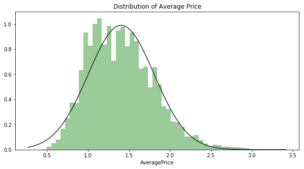

```python
# Univariate distribution of all average price in the dataset
plt.figure(figsize=(10,5)) # Make visualization longer horizontally
plt.title("Distribution of Average Price")
sns.distplot(avocado["AveragePrice"], color="g", fit=norm, kde=False) # distplot via seaborn

mean = avocado["AveragePrice"].mean()
print("Mean price of a single avocado: $%.2f" % (round(mean, 2))) # Printing out the overall mean price of an avocado
```

It seems that the average price of avocados from 2015-2018 is around $ 1.41 per avocado. That is expensive!

But what about these outliers? There were instances of prices that are weirdly more priced than the average (Some close to being 3 dollars per avocado)

Now let's try visualizing average total volume of avocados sold per region:

```python
avocado1 = avocado # Making temp dataframe to do visualization with
avocado1 = avocado[avocado.region != "TotalUS"] # Excluding US region total

avg_total_volume = []
avg_price = []
region = list(avocado1.region.unique())

for i in region: # Appends region average sum of volume sold
    x = avocado1[avocado1.region==i]
    avg_total_volume.append(sum(x["Total Volume"])/len(x))

temp = pd.DataFrame({"Region" : region, "AverageVolume" : avg_total_volume})
new = temp.AverageVolume.sort_values(ascending=False).index.values
sortdf = temp.reindex(new)
```

Visualizing Total Volume According to Region

```
Text(0,0.5,'Average Total Volume')
```

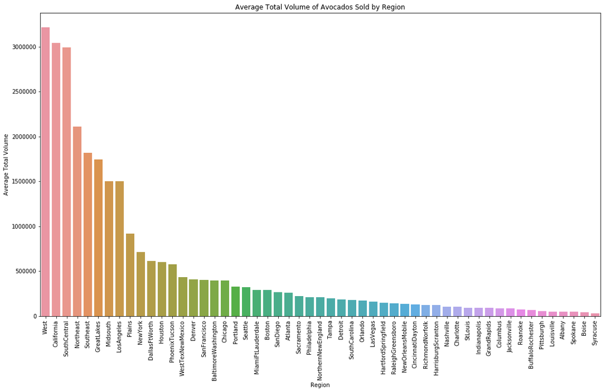

```python
plt.figure(figsize=(18,10)) # Making plot more easier to read and see

sns.barplot(x=sortdf.Region, y=sortdf.AverageVolume) # seaborn barplot

# Labeling and fixing x-label
plt.title("Average Total Volume of Avocados Sold by Region")
plt.xticks(rotation=90)
plt.xlabel("Region")
plt.ylabel("Average Total Volume")
```

*Note that these aren't exclusive to cities or states, it also includes regions of the USA like West, Plains, etc...*

**How about conventional vs. organic avocados price ranging months?**

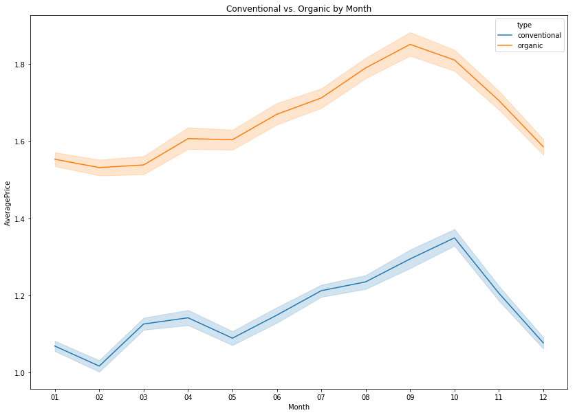

```python
plt.figure(figsize=(14,10))
plt.title("Conventional vs. Organic by Month")
sns.lineplot(x="Month", y="AveragePrice", hue="type", data=avocado) # line graph between conventional vs organic avocados
```

Obviously, organic avocados are more expensive than conventional avocados. But, it is observable that the average price of avocados for both organic and conventional avocados soars in price in the month of September through October.

**How about the historical plot of average price of avocados throughout the entire date range of the dataset?**

```
Text(0.5,1,'Historical Average Price')
```

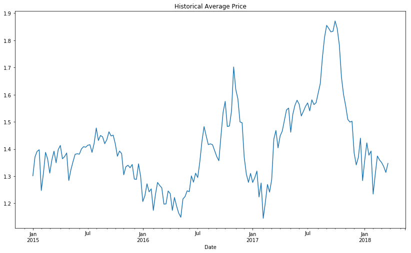

```python
avocadoByDate = avocadoDate.groupby("Date").mean() # sorting by the datetime in avocadoDate dataframe
plt.figure(figsize=(14,8))
avocadoByDate["AveragePrice"].plot() # plotting simple line plot
plt.title("Historical Average Price")
```

It seems that there was a massive price hike around September and October of 2017, even higher than the previous influx of price in September and October in the previous years.

So what is causing this massive price hike in 2017?

```
Text(16.3,0.5,'Total Volume')
```

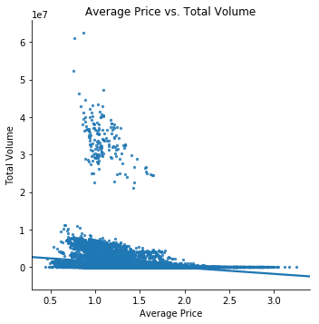

```python
#plotting average price vs. total volume of avocados
sns.lmplot("AveragePrice", "Total Volume", data=avocado, scatter_kws={"s": 5})
plt.title("Average Price vs. Total Volume")
plt.xlabel("Average Price")
plt.ylabel("Total Volume")
```

We see that there is some steep correlation of volume dictatingaverage price. As the total volume of available avocados fall, the price rises.

Let's see if supply has anything to do with the date, particularly in September and October.

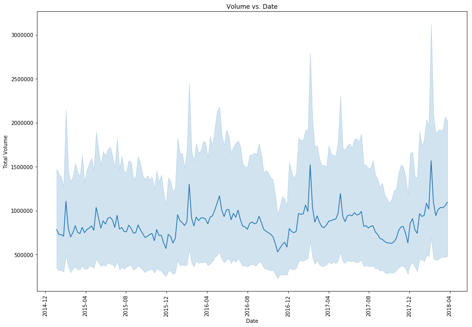

```python
plt.figure(figsize=(15,10))
sns.lineplot("Date", "Total Volume", data=avocadoDate)
plt.title("Volume vs. Date")
plt.xticks(rotation=90)
```

Now we start seeing some correlation between prices and total volume and date. As the volume decreases, the price hikes (simple concept of supply and demand) in the months where supply is low. But as we've seen above, this price increase is especially rampant during the month of September and October in 2017. In fact, it was the highest it has ever been.

### Conclusion

**So what is causing these price increase?**

There are multiple causes! (source: https://www.cheatsheet.com/culture/why-avocados-are-so-expensive.hyml/)

- The season: growing season is peak February and September, which means other months the harvest is less
- Excessive heat: Extreme heatwaves in 2017 made avocados scarce
- Drought: Excessive drought in California 2017 caused less harvest
- Fire: Wildfire of California burned severe damage to avocado trees
- Supply and demand: Ever increasing demand of Avocado (see Avocado Toast)

So it seems that the data was pointing us to the right direction, that volume, date and average price are somewhat correlated, and California as one of the main exporter of avocados and onen of the highest volume of avocados purchased, we can see that the supply dip in the month of October and September do indeed play the role in the average price fluctuations. And the listed factors for 2017 make sense to why avocados' average price was highest it has ever been in this dataset due to lack of supply to the vast demand.

### References

https://www.cheatsheet.com/culture/why-avocados-are-so-expensive.html/

https://www.kaggle.com/neuromusic/avocado-prices

https://www.californiaavocado.com/avocado101/the-california-difference/fun-avocado-facts